# STORM & FLOOD FORECAST

## Load packages:

```python
library(dplyr)
library(ggplot2)
library(forecast)
```

## Part 1: Data

I upload the time series from 1900 to 2021 of the disasters in the world:

**Load data:**

```python
data <- read.csv("../input/all-natural-disasters-19002021-eosdis/DISASTERS/1900_2021_DISASTERS.xlsx - emdat data.csv", stringsAsFactors = T)
```

There are missing values in the dataset but Year, Disaster.Type, Disaster.Subtype and Continent variables don't have any, so I don't consider the missing values problem:

```python
colSums(is.na(data))
```

**Year**

0

**Seq**

0

**Glide**

0

**Disaster.Group**

0

**Disaster.Subgroup**

0

**Disaster.Type**

0

**Disaster.Subtype**

0

**Disaster.Subsubtype**

0

**Event.Name**

0

**Country**

0

**ISO**

0

**Region**

0

**Continent**

0

**Location**

0

**Origin**

0

**Associated.Dis**

0

**Associated.Dis2**

0

**OFDA.Response**

0

**Appeal**

0

**Declaration**

0

**Aid.Contribution**

15449

**Dis.Mag.Value**

11180

**Dis.Mag.Scale**

0

**Latitude**

0

**Longitude**

0

**Local.Time**

0

**River.Basin**

0

**Start.Year**

0

**Start.Month**

387

**Start.Day**

3628

**End.Year**

0

**End.Month**

708

**End.Day**

3556

**Total.Deaths**

4713

**No.Injured**

12231

**No.Affected**

6906

**No.Homeless**

13696

**Total.Affected**

4509

**Insured.Damages...000.US..**

15030

**Total.Damages...000.US..**

10881

**CPI**

315

**Adm.Level**

0

**Admin1.Code**

0

**Admin2.Code**

0

**Geo.Locations**

0

Values of categorical variables in the dataset:

```python
levels(data$Disaster.Subgroup)
print("Disaster.Type:")
levels(data$Disaster.Type)
print("Disaster.Subtype:")
levels(data$Disaster.Subtype)
print("Disaster.Subsubtype:")
levels(data$Disaster.Subsubtype)
print("Continent:")
levels(data$Continent)
print("Region:")
levels(data$Region)
```

1. 'Biological'

2. 'Climatological'

3. 'Extra-terrestrial'

4. 'Geophysical'

5. 'Hydrological'

6. 'Meteorological'

```
[1] "Disaster.Type:"
```

1. 'Animal accident'

2. 'Drought'

3. 'Earthquake'

4. 'Epidemic'

5. 'Extreme temperature '

6. 'Flood'

7. 'Fog'

8. 'Glacial lake outburst'

9. 'Impact'

10. 'Insect infestation'

11. 'Landslide'

12. 'Mass movement (dry)'

13. 'Storm'

14. 'Volcanic activity'

15. 'Wildfire'

```
[1] "Disaster.Subtype:"
```

1. ''

2. 'Ash fall'

3. 'Avalanche'

4. 'Bacterial disease'

5. 'Coastal flood'

6. 'Cold wave'

7. 'Convective storm'

8. 'Drought'

9. 'Extra-tropical storm'

10. 'Flash flood'

11. 'Forest fire'

12. 'Grasshopper'

13. 'Ground movement'

14. 'Heat wave'

15. 'Land fire (Brush, Bush, Pasture)'

16. 'Landslide'

17. 'Lava flow'

18. 'Locust'

19. 'Mudslide'

20. 'Parasitic disease'

21. 'Pyroclastic flow '

22. 'Riverine flood'

23. 'Rockfall'

24. 'Severe winter conditions'

25. 'Subsidence'

26. 'Tropical cyclone'

27. 'Tsunami'

28. 'Viral disease'

```
[1] "Disaster.Subsubtype:"
```

1. ''

2. 'Derecho'

3. 'Hail'

4. 'Lightning/Thunderstorms'

5. 'Mudslide'

6. 'Rain'

7. 'Sand/Dust storm'

8. 'Severe storm'

9. 'Snow/Ice'

10. 'Storm/Surge'

11. 'Sudden subsidence'

12. 'Tornado'

13. 'Winter storm/Blizzard'

```
[1] "Continent:"
```

1. 'Africa'

2. 'Americas'

3. 'Asia'

4. 'Europe'

5. 'Oceania'

```
[1] "Region:"
```

1. 'Australia and New Zealand'

2. 'Caribbean'

3. 'Central America'

4. 'Central Asia'

5. 'Eastern Africa'

6. 'Eastern Asia'

7. 'Eastern Europe'

8. 'Melanesia'

9. 'Micronesia'

10. 'Middle Africa'

11. 'Northern Africa'

12. 'Northern America'

13. 'Northern Europe'

14. 'Polynesia'

15. 'Russian Federation'

16. 'South America'

17. 'South-Eastern Asia'

18. 'Southern Africa'

19. 'Southern Asia'

20. 'Southern Europe'

21. 'Western Africa'

22. 'Western Asia'

23. 'Western Europe'

## Part 2: Research question

We want to predict the frequency of the main disasters (Floods and Storms) from 2022 onwards and evaluate if there is an increasing trend in the time series of these disasters.

## Part 3: EDA

As can be seen from the following graph, the most frequent disasters in the dataset are Floods and Storms

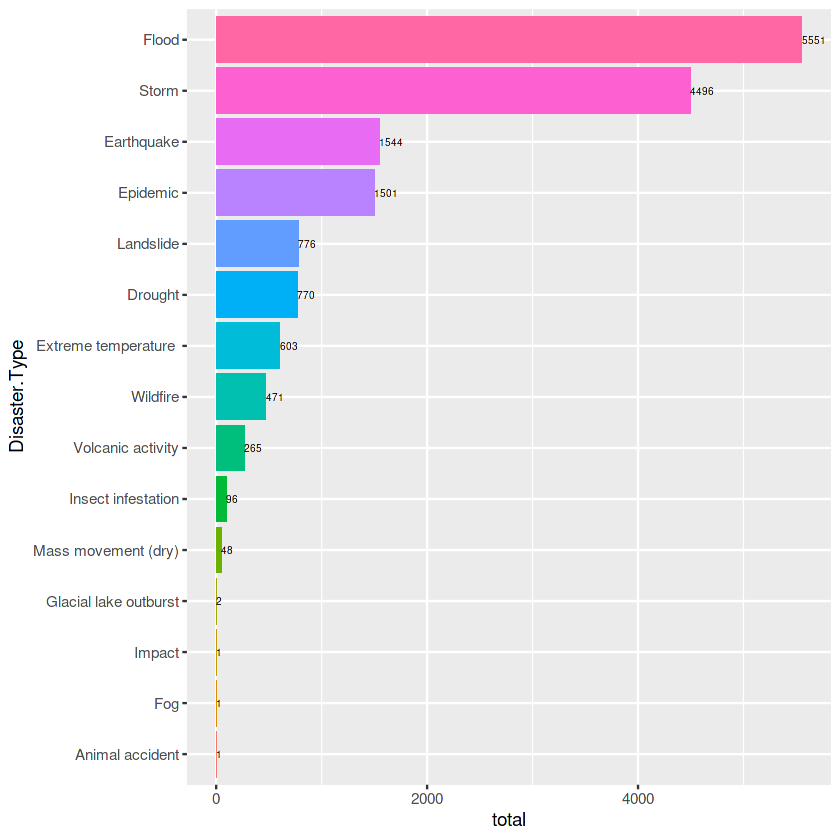

```python
df<-data %>%
  group_by(Disaster.Type) %>%
  summarise(total=n())

df %>%
mutate(Disaster.Type=reorder(Disaster.Type,total))  %>%
  ggplot(aes(Disaster.Type,total, fill=Disaster.Type)) +
  geom_bar(stat = "identity")+
  coord_flip()+
  geom_text(aes(label=total), hjust=0, size=2)+
  guides(fill="none")
```

An increasing trend of these disasters in the time series from 1900 to 2021 and also of tropical cyclones can be seen from the following graphs:

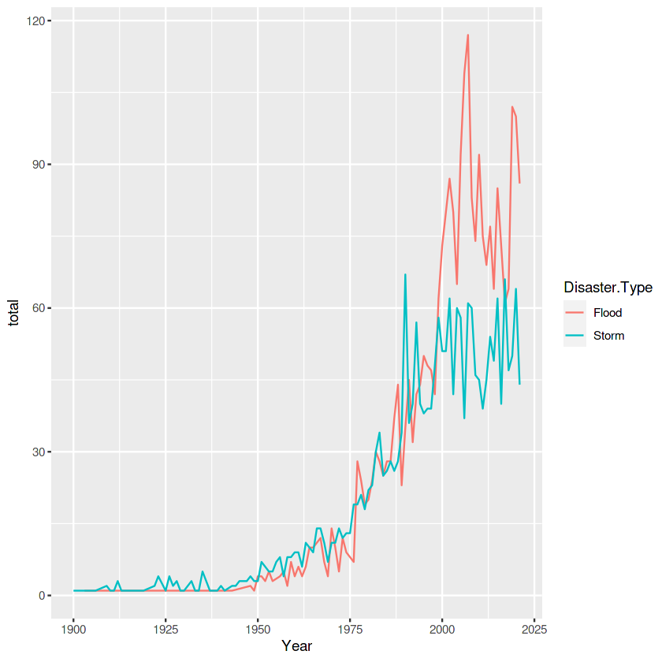

```python
data %>%
  filter(Disaster.Type==c("Flood","Storm")) %>%
  group_by(Disaster.Type, Year) %>%
  summarise(total=n()) %>%
  ggplot(aes(Year,total, colour=Disaster.Type)) +
  geom_line()
```

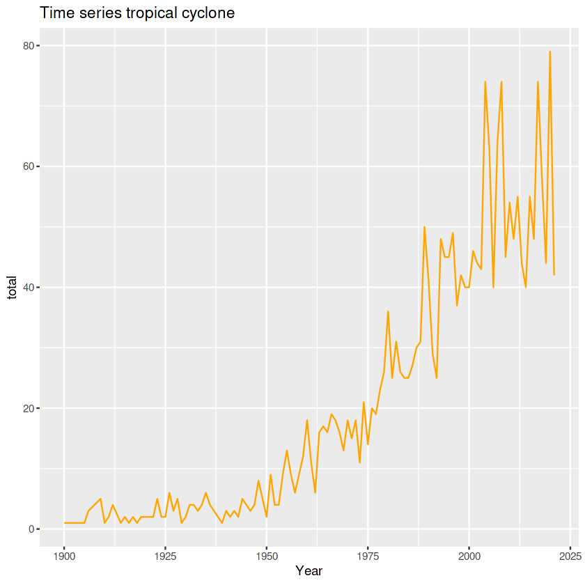

```python
data %>%
  filter(Disaster.Subtype=="Tropical cyclone") %>%
  group_by(Year) %>%
  summarise(total=n()) %>%
  ggplot(aes(Year,total)) +
  geom_line(colour="Orange")+
  ggtitle("Time series tropical cyclone")
```

I create a function to evaluate the total number of Floods and Storms per continent and the related time series and it is noted that the trends are growing for all continents and then stabilize in recent years:

```python
View_disaster_per_continent <- function(Disaster) {

  df<-data %>%
    filter(Disaster.Type==Disaster) %>%
    group_by(Continent) %>%
    summarise(total=n()) %>%
    arrange(desc(total))


  g<- data %>%
    filter(Disaster.Type==Disaster) %>%
    group_by(Continent,Year) %>%
    summarise(total=n()) %>%
    ggplot(aes(Year,total, colour=Continent)) +
    geom_line()+
    ggtitle(Disaster)

  print(df)
  print(g)
}
```

```
# A tibble: 5 × 2
  Continent total
  <fct>     <int>
1 Asia       2303
2 Americas   1275
3 Africa     1147
4 Europe      668
5 Oceania     158
```

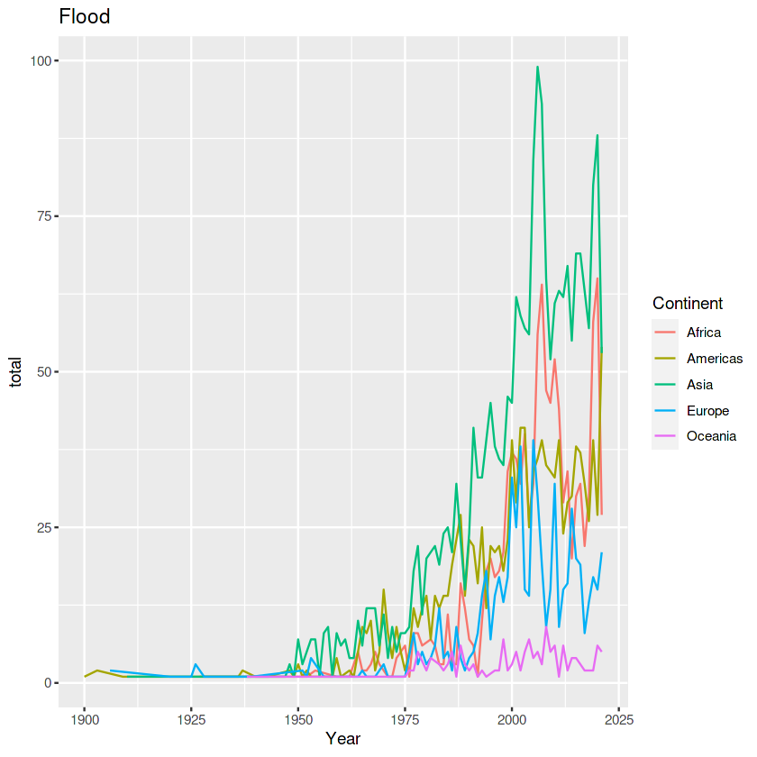

```python
View_disaster_per_continent("Flood")
```

```
# A tibble: 5 × 2
  Continent total
  <fct>     <int>
1 Asia       1884
2 Americas   1442
3 Europe      542
4 Oceania     338
5 Africa      290
```

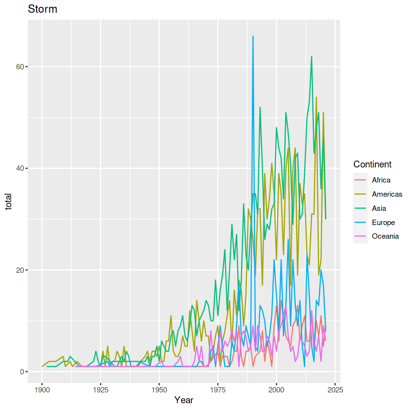

```python
View_disaster_per_continent("Storm")
```

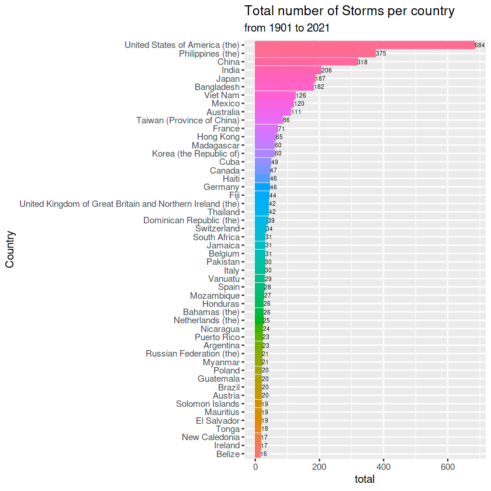

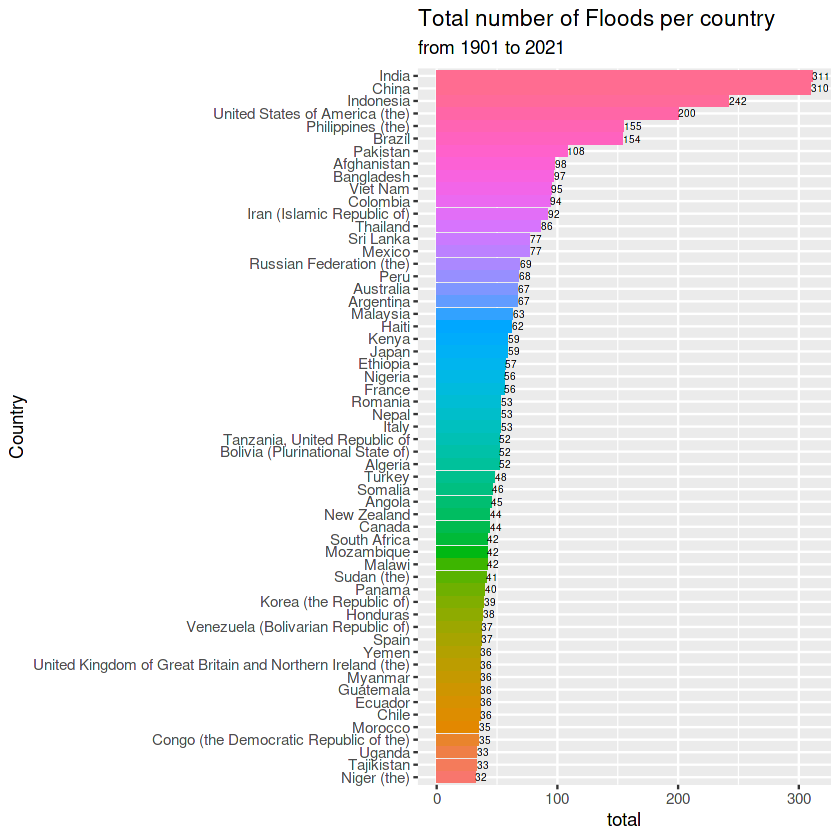

```python
df<-data %>%
  filter(Disaster.Type=="Storm") %>%
  group_by(Country) %>%
  summarise(total=n())

g<-df %>%
filter(total>15) %>%
mutate(Country=reorder(Country,total))  %>%
  ggplot(aes(Country,total, fill=Country)) +
  geom_bar(stat = "identity")+
  coord_flip()+
  geom_text(aes(label=total), hjust=0, size=2)+
  guides(fill="none")+
  ggtitle("Total number of Storms per country", subtitle="from 1901 to 2021")

df<-data %>%
  filter(Disaster.Type=="Flood") %>%
  group_by(Country) %>%
  summarise(total=n())

print(g)

g<-df %>%
filter(total>30) %>%
mutate(Country=reorder(Country,total))  %>%
  ggplot(aes(Country,total, fill=Country)) +
  geom_bar(stat = "identity")+
  coord_flip()+
  geom_text(aes(label=total), hjust=0, size=2)+
  guides(fill="none")+
  ggtitle("Total number of Floods per country", subtitle="from 1901 to 2021")

print(g)
```

## Part 4: Forecasting

I compare the ets forecasting model with the arima model by calculating the forecast errors by dividing the time series into a train and a test. It is noted that the arima model gives minor errors on the test and therefore is better:

```python
dis<-data %>%
    filter(Disaster.Type=="Storm") %>%
    group_by(Year) %>%
    summarise(total=n())

#training and test sets
train <- ts(dis[1:105,2])
test <- ts(dis[106:118,2])
```

```python
fc_ets <- forecast(train,12)
acc_ets <- accuracy(fc_ets, test[1:12])
acc_ets
```

A matrix: 2 × 7 of type dbl

|  | ME | RMSE | MAE | MPE | MAPE | MASE | ACF1 |
| --- | --- | --- | --- | --- | --- | --- | --- |
| Training set | 1.152539 | 11.25402 | 5.671677 | -23.07858 | 41.24319 | 0.8573465 | -0.2161825 |
| Test set | -9.097916 | 17.43204 | 16.439080 | -11.28687 | 17.06459 | 2.4849771 | NA |

```python
ar <- auto.arima(train)
fc_arima <- forecast(ar,12)
acc_arima <- accuracy(fc_arima, test[1:12])
acc_arima
```

A matrix: 2 × 7 of type dbl

|  | ME | RMSE | MAE | MPE | MAPE | MASE | ACF1 |
| --- | --- | --- | --- | --- | --- | --- | --- |
| Training set | -0.006098709 | 10.11330 | 5.286694 | -46.551056 | 56.65213 | 0.7991514 | 0.005505753 |
| Test set | -5.865769247 | 15.49559 | 13.954389 | -7.832744 | 14.22381 | 2.1093844 | NA |

```python
forecast_disaster <- function( Disaster) {
  dis<-data %>%
    filter(Disaster.Type==Disaster) %>%
    group_by(Year) %>%
    summarise(total=n())

  serie <-ts(dis$total)
  ar <- auto.arima(serie)
  fore<-forecast(ar)

  plot(fore)

  year<-2022:2031
  df_pred <-data.frame(q=99:108)
  p<-predict (fore,newdata=df_pred, se=TRUE)
  cat("Forecasting",Disaster,"\n")
  cbind(as.data.frame(year),p)
 }
```

```
Forecasting Flood
```

A data.frame: 10 × 6

|  | year <int> | Point Forecast <dbl> | Lo 80 <dbl> | Hi 80 <dbl> | Lo 95 <dbl> | Hi 95 <dbl> |
| --- | --- | --- | --- | --- | --- | --- |
| 99 | 2022 | 163.3080 | 144.2550 | 182.3611 | 134.1689 | 192.4472 |
| 100 | 2023 | 186.3730 | 160.3882 | 212.3578 | 146.6326 | 226.1133 |
| 101 | 2024 | 185.8720 | 158.6080 | 213.1359 | 144.1754 | 227.5685 |
| 102 | 2025 | 177.2149 | 148.3008 | 206.1291 | 132.9946 | 221.4353 |
| 103 | 2026 | 180.9210 | 148.6942 | 213.1477 | 131.6345 | 230.2075 |
| 104 | 2027 | 187.8025 | 152.9734 | 222.6317 | 134.5360 | 241.0691 |
| 105 | 2028 | 188.2784 | 151.7580 | 224.7989 | 132.4253 | 244.1316 |
| 106 | 2029 | 187.6336 | 149.2979 | 225.9693 | 129.0042 | 246.2630 |
| 107 | 2030 | 190.2696 | 149.8789 | 230.6603 | 128.4973 | 252.0419 |
| 108 | 2031 | 193.2271 | 151.0031 | 235.4511 | 128.6511 | 257.8031 |

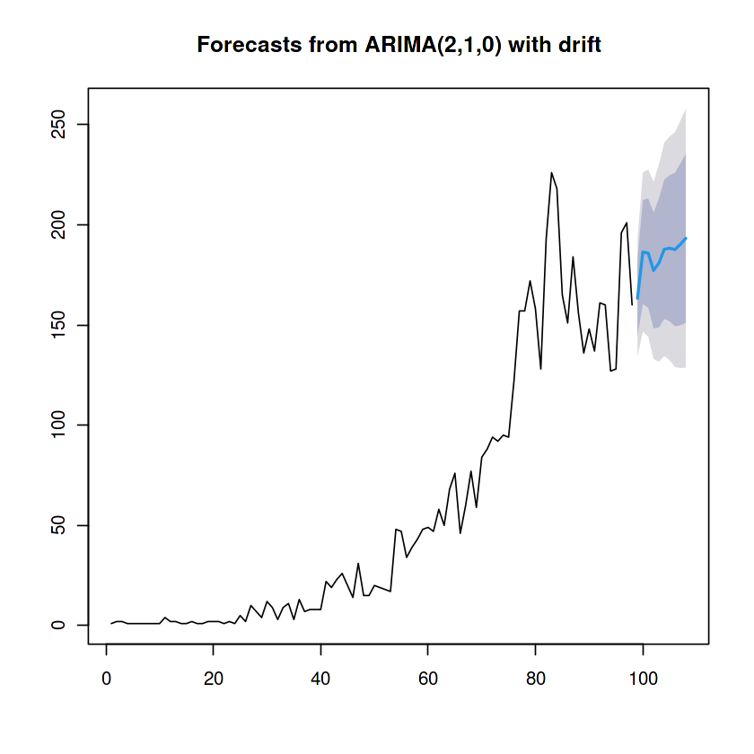

```python
forecast_disaster("Flood")
```

```
Forecasting Storm
```

A data.frame: 10 × 6

|  | year <int> | Point Forecast <dbl> | Lo 80 <dbl> | Hi 80 <dbl> | Lo 95 <dbl> | Hi 95 <dbl> |
| --- | --- | --- | --- | --- | --- | --- |
| 119 | 2022 | 106.96683 | 92.58186 | 121.3518 | 84.96692 | 128.9667 |
| 120 | 2023 | 112.42125 | 97.74714 | 127.0954 | 89.97913 | 134.8634 |
| 121 | 2024 | 95.83292 | 80.75905 | 110.9068 | 72.77942 | 118.8864 |
| 122 | 2025 | 112.64411 | 95.00880 | 130.2794 | 85.67323 | 139.6150 |
| 123 | 2026 | 106.25835 | 88.39740 | 124.1193 | 78.94238 | 133.5743 |
| 124 | 2027 | 106.08475 | 87.11730 | 125.0522 | 77.07653 | 135.0930 |
| 125 | 2028 | 112.04641 | 92.12455 | 131.9683 | 81.57856 | 142.5143 |
| 126 | 2029 | 108.13206 | 87.71808 | 128.5460 | 76.91157 | 139.3526 |
| 127 | 2030 | 111.28626 | 89.90959 | 132.6629 | 78.59346 | 143.9791 |
| 128 | 2031 | 112.38255 | 90.37158 | 134.3935 | 78.71967 | 146.0454 |

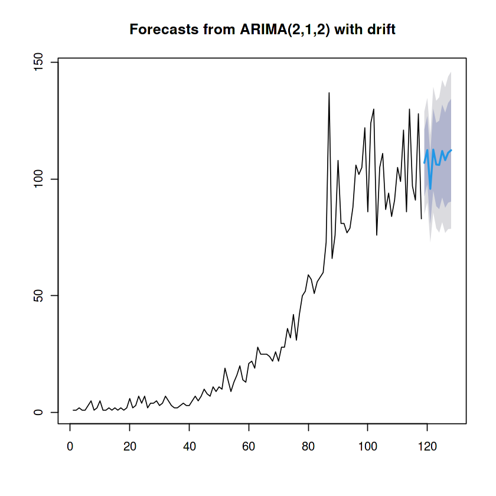

```python
forecast_disaster("Storm")
```